# More JSON Practice: Nobel Prize Data

## Overview

For this assignment we will use the public Nobel Prize API (version 2.1) to pull laureate data in JSON format, transform it into a tidy data frame in R, and answer four questions:

1. What is the gender breakdown of Nobel laureates?
2. Which countries have produced the most laureates?
3. How often is a prize shared?
4. How old were laureates when they won, and how does that relate to the size of the team and the size of the prize?

## Obtaining the JSON data

The API returns laureates in pages, so we loop through the pages using `offset` until a page comes back empty. The JSON is kept as nested lists (`simplifyVector = FALSE`) so we can control exactly how it gets flattened.

```r
library(jsonlite)
library(tidyverse)
```

```r
base_url <- "https://api.nobelprize.org/2.1/laureates"

# function to request one page of 100 laureates and return the list of laureates
get_page <- function(offset, limit = 100) {
  url <- sprintf("%s?offset=%d&limit=%d", base_url, offset, limit)
  fromJSON(url, simplifyVector = FALSE)$laureates
}

# keep requesting pages until there is nothing left
all_laureates <- list()
offset <- 0
repeat {
  page <- get_page(offset)
  if (length(page) == 0) break
  all_laureates <- c(all_laureates, page)
  offset <- offset + 100
}

length(all_laureates)
```

```
[1] 1028
```

## Tidying the JSON

A laureate can have more than one prize (Marie Curie won twice), so we build one row per laureate and prize. Organizations such as the Red Cross have no gender or birth date, so those fields will be `NA` for them.

```r
get_value <- function(x, ...) {
  v <- purrr::pluck(x, ..., .default = NA)
  if (is.null(v) || length(v) == 0) NA else v
}

# convert the portion of a prize ("1", "1/2", "1/3", "1/4") into a number
portion_to_number <- function(x) {
  map_dbl(x, function(s) {
    if (is.na(s)) return(NA_real_)
    p <- as.numeric(strsplit(s, "/")[[1]])
    if (length(p) == 1) p else p[1] / p[2]
  })
}

# one row for each prize each laureate received
nobel <- map_dfr(all_laureates, function(l) {
  map_dfr(l$nobelPrizes, function(p) {
    tibble(
      id            = get_value(l, "id"),
      name          = coalesce(get_value(l, "knownName", "en"),
                               get_value(l, "orgName", "en")),
      gender        = get_value(l, "gender"),
      birth_date    = get_value(l, "birth", "date"),
      birth_country = get_value(l, "birth", "place", "countryNow", "en"),
      award_year    = as.integer(get_value(p, "awardYear")),
      category      = get_value(p, "category", "en"),
      portion       = get_value(p, "portion"),
      prize_adj     = get_value(p, "prizeAmountAdjusted")
    )
  })
}) %>%
  mutate(
    # birth dates are sometimes partial so only the year is used
    birth_year = suppressWarnings(as.integer(substr(birth_date, 1, 4))),
    # approximate age at the time of the award
    age = award_year - birth_year,
    # the laureate's own share of the (inflation adjusted) prize money
    share = portion_to_number(portion),
    laureate_prize = prize_adj * share
  ) %>%
  # team size is the number of laureates who received the same prize
  group_by(award_year, category) %>%
  mutate(team_size = n()) %>%
  ungroup()

glimpse(nobel)
```

```
Rows: 1,036
Columns: 14
$ id             <chr> "745", "102", "779", "259", "1004", "114", "982", "981"…
$ name           <chr> "A. Michael Spence", "Aage N. Bohr", "Aaron Ciechanover…
$ gender         <chr> "male", "male", "male", "male", "male", "male", "male",…
$ birth_date     <chr> "1943-11-07", "1922-06-19", "1947-10-01", "1926-08-11",…
$ birth_country  <chr> "USA", "Denmark", "Israel", "Lithuania", NA, "Pakistan"…
$ award_year     <int> 2001, 1975, 2004, 1982, 2021, 1979, 2019, 2019, 2009, 2…
$ category       <chr> "Economic Sciences", "Physics", "Chemistry", "Chemistry…
$ portion        <chr> "1/3", "1/3", "1/3", "1", "1", "1/3", "1/3", "1", "1/3"…
$ prize_adj      <int> 15547541, 4304697, 14874529, 3923237, 12096939, 3778486…
$ birth_year     <int> 1943, 1922, 1947, 1926, 1948, 1926, 1961, 1976, 1939, 1…
$ age            <int> 58, 53, 57, 56, 73, 53, 58, 43, 70, 42, 36, 70, 52, 49,…
$ share          <dbl> 0.3333333, 0.3333333, 0.3333333, 1.0000000, 1.0000000, …
$ laureate_prize <dbl> 5182514, 1434899, 4958176, 3923237, 12096939, 1259495, …
$ team_size      <int> 3, 3, 3, 1, 1, 3, 3, 1, 3, 3, 2, 1, 1, 1, 1, 3, 3, 2, 3…
```

## Question 1: Gender of laureates

Organizations do not have a gender, so they are left out. Each person is counted once even if they won more than once.

```r
# overall count of unique people by gender
nobel %>%
  filter(!is.na(gender)) %>%
  distinct(id, gender) %>%
  count(gender) %>%
  mutate(percent = round(n / sum(n) * 100, 1))
```

```
# A tibble: 2 × 3
  gender     n percent
  <chr>  <int>   <dbl>
1 female    69     6.9
2 male     931    93.1
```

```r
# count of prizes by category and gender
gender_category <- nobel %>%
  filter(!is.na(gender)) %>%
  count(category, gender) %>%
  group_by(category) %>%
  mutate(percent = round(n / sum(n) * 100, 1)) %>%
  ungroup()

gender_category
```

```
# A tibble: 12 × 4
   category               gender     n percent
   <chr>                  <chr>  <int>   <dbl>
 1 Chemistry              female     8     4
 2 Chemistry              male     194    96
 3 Economic Sciences      female     3     3
 4 Economic Sciences      male      98    97
 5 Literature             female    19    15.4
 6 Literature             male     104    84.6
 7 Peace                  female    21    18.6
 8 Peace                  male      92    81.4
 9 Physics                female     5     2.2
10 Physics                male     226    97.8
11 Physiology or Medicine female    14     6
12 Physiology or Medicine male     221    94
```

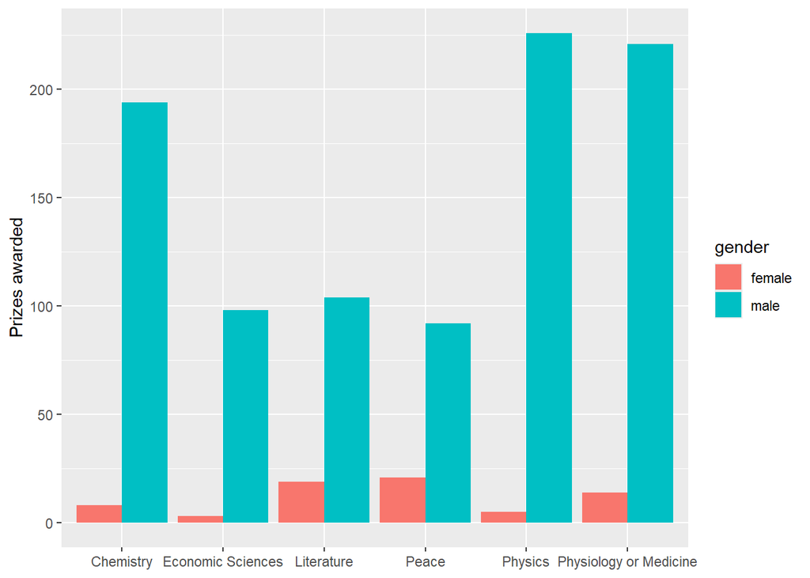

```r
ggplot(gender_category, aes(category, n, fill = gender)) +
  geom_col(position = "dodge") +
  labs(x = NULL, y = "Prizes awarded")
```

## Question 2: Countries of laureates

Here we use the country where each laureate was born, using the modern name of the country (`countryNow`) so that places like the former USSR are not counted separately.

```r
# top 15 birth countries
top_countries <- nobel %>%
  filter(!is.na(birth_country)) %>%
  count(birth_country, sort = TRUE) %>%
  slice_head(n = 15)

top_countries
```

```
# A tibble: 15 × 2
   birth_country       n
   <chr>           <int>
 1 USA               302
 2 United Kingdom     95
 3 Germany            86
 4 France             64
 5 Japan              31
 6 Sweden             30
 7 Poland             29
 8 Russia             29
 9 Canada             23
10 Italy              20
11 the Netherlands    20
12 Austria            19
13 Switzerland        19
14 Norway             13
15 China              12
```

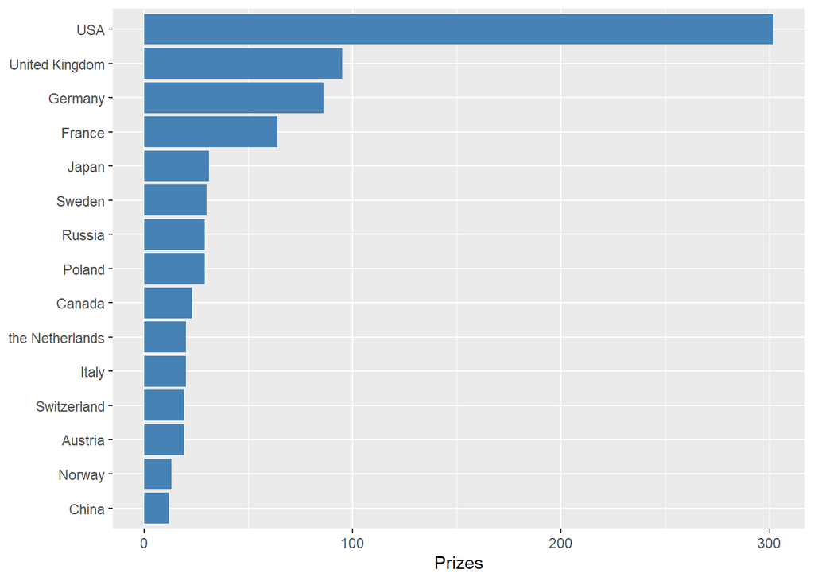

```r
ggplot(top_countries, aes(n, reorder(birth_country, n))) +
  geom_col(fill = "steelblue") +
  labs(x = "Prizes", y = NULL)
```

## Question 3: How often is a prize shared?

A prize is one category in one year. It is considered shared when more than one laureate receives it.

```r
# one row for each prize with the number of laureates
prizes <- nobel %>%
  distinct(award_year, category, team_size) %>%
  mutate(shared = team_size > 1)

# how many prizes were won by teams of each size
prizes %>%
  count(team_size) %>%
  mutate(percent = round(n / sum(n) * 100, 1))
```

```
# A tibble: 3 × 3
  team_size     n percent
      <int> <int>   <dbl>
1         1   365    57.1
2         2   151    23.6
3         3   123    19.2
```

```r
# overall proportion of prizes that are shared
mean(prizes$shared)
```

```
[1] 0.428795
```

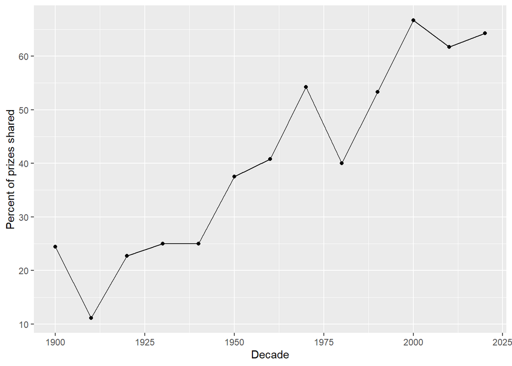

```r
# how the percent of shared prizes has changed by decade
shared_decade <- prizes %>%
  group_by(decade = award_year %/% 10 * 10) %>%
  summarise(percent_shared = mean(shared) * 100)

ggplot(shared_decade, aes(decade, percent_shared)) +
  geom_line() +
  geom_point() +
  labs(x = "Decade", y = "Percent of prizes shared")
```

## Question 4: Age, team size, and prize size

Ages of 0 or less come from missing or partial birth dates and are removed. The prize size is each laureate’s own share of the inflation adjusted prize money, since a bigger team means a smaller piece for each person.

```r
laureate_age <- nobel %>%
  filter(!is.na(age), age > 0)

# overall summary of age at award
summary(laureate_age$age)
```

```
   Min. 1st Qu.  Median    Mean 3rd Qu.    Max.
  17.00   52.00   61.00   60.61   70.00   97.00
```

```r
# age by team size
laureate_age %>%
  group_by(team_size) %>%
  summarise(laureates = n(),
            mean_age = round(mean(age), 1),
            median_age = median(age))
```

```
# A tibble: 3 × 4
  team_size laureates mean_age median_age
      <int>     <int>    <dbl>      <dbl>
1         1       346     59.6         60
2         2       292     59.6         60
3         3       367     62.4         62
```

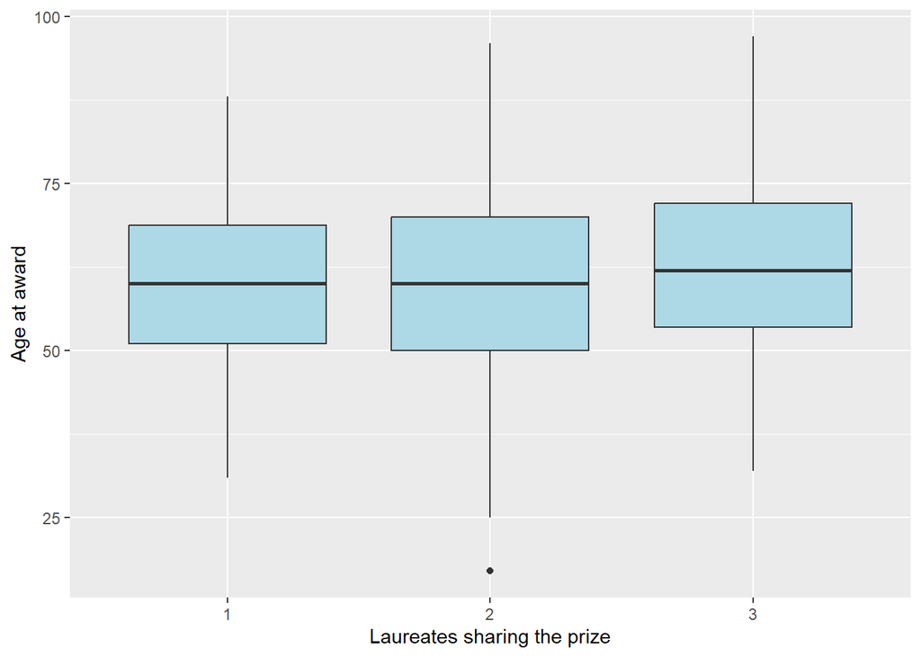

```r
ggplot(laureate_age, aes(factor(team_size), age)) +
  geom_boxplot(fill = "lightblue") +
  labs(x = "Laureates sharing the prize", y = "Age at award")
```

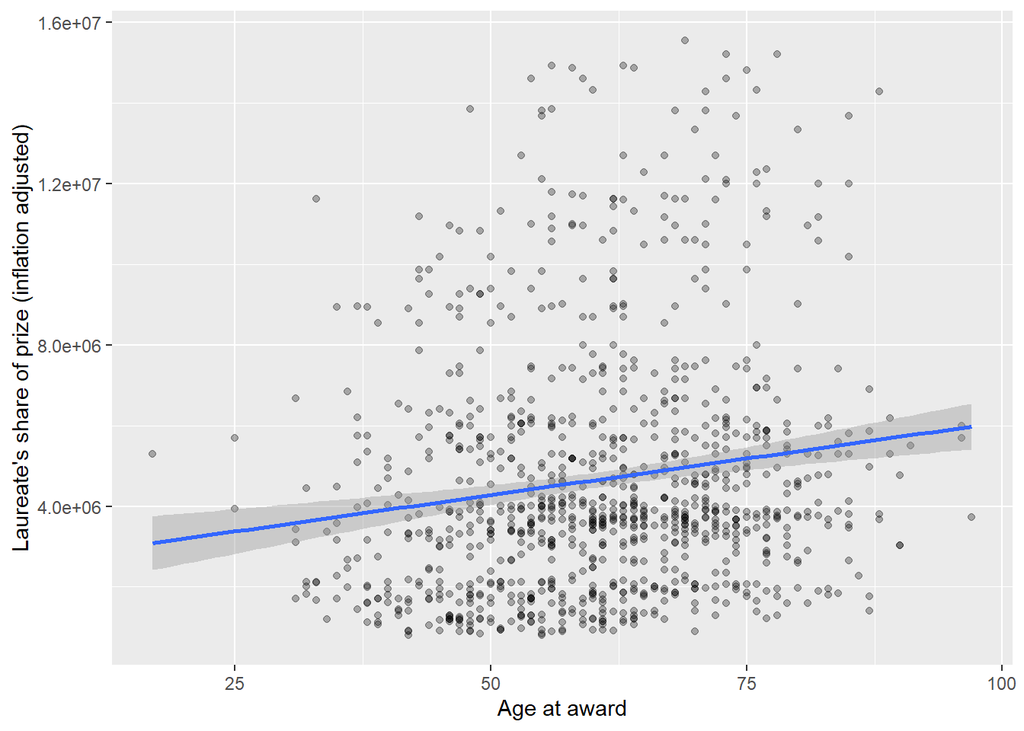

```r
# age against the size of the laureate's own prize
laureate_age %>%
  filter(!is.na(laureate_prize)) %>%
  ggplot(aes(age, laureate_prize)) +
  geom_point(alpha = 0.3) +
  geom_smooth(method = "lm") +
  labs(x = "Age at award", y = "Laureate's share of prize (inflation adjusted)")
```

```r
# correlation of age with team size and with prize size
laureate_age %>%
  summarise(age_vs_team_size = cor(age, team_size),
            age_vs_prize = cor(age, laureate_prize, use = "complete.obs"))
```

```
# A tibble: 1 × 2
  age_vs_team_size age_vs_prize
             <dbl>        <dbl>
1           0.0953        0.151
```

## Final Analysis

The gender breakdown should show that men make up the large majority of laureates, with women having the most representation in the Peace and Literature categories. The country counts should be led by the United States, followed by European countries such as the United Kingdom, Germany, and France. Counting by birth country also hides the fact that many laureates did their prize winning work somewhere else.

Sharing a prize is the norm rather than the exception in recent decades, and the percent of shared prizes has generally risen over time, especially in the science categories where discoveries often come from several researchers. This matters for the last question, because the money for a prize is fixed and each additional laureate means a smaller portion for everyone.

Finally, laureates tend to be in their late 50s or 60s when they win, which makes sense because many prizes recognize work that took decades to be accepted. Age should only be weakly related to team size, and the size of an individual prize depends much more on the year and on the number of people sharing it than on how old the winner is. One shortcoming is that age here is only approximate since it is the award year minus the birth year, and the inflation adjusted prize amount mostly reflects when the prize was won rather than who won it.